# Kaggle Part 2

Angel Claudio

3/19/2020

# Kaggle DS survery 2019 - PART TWO

## Open Connection to Database

```r
conn <- dbConnect(odbc(),
                  Driver = "SQL Server",
                  Server = "spsangelclaudio.database.windows.net",
                  Database = "DataScienceValue",
                  UID = "spsadmin",
                  PWD = "bKuNsh6bphei23c")
```

## Get View Object for Use

```r
#kaggle_data <- tbl(conn, "uvwParticipantData")
kaggle_data <- dbGetQuery(conn, 'Select * from uvwParticipantData')
```

## Check for outliers

There are no possible numeric outliers as users did not input numbers by hand but instead chose a bin provided by the survey writers.

## Cleaning Salary data

I will clean salary data to make it numeric, allowing it to be easily plotted.

```r
##This function takes numeric bins and returns the mean of the bin, allowing us to more easily order/graph them.
clean_numeric_bins <- function(series){
  series <- str_remove_all(series, '[,><+/s]') %>%  str_split('-')
  series <- sapply(series, as.integer) %>% sapply(mean) %>% sapply(round)
  series
}



df_basic <- kaggle_data
df_basic$Salary <- clean_numeric_bins(df_basic$Salary)
```

## Do age and gender affect compensation?

### Univariate Plots

First we examine the distributions of age, gender, and compensation on their own.

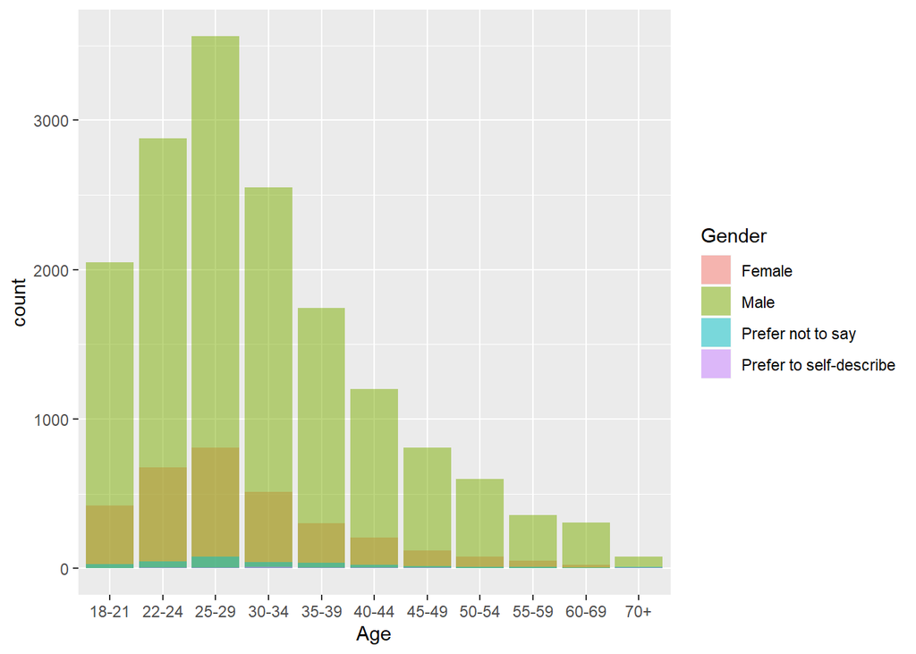

```r
df_basic %>% ggplot(aes(x = Age, fill = Gender)) + geom_histogram(alpha = 0.5, stat = 'count', position = 'identity')
```

```r
mean(df_basic$Gender == 'Male')
```

```
## [1] 0.8184815
```

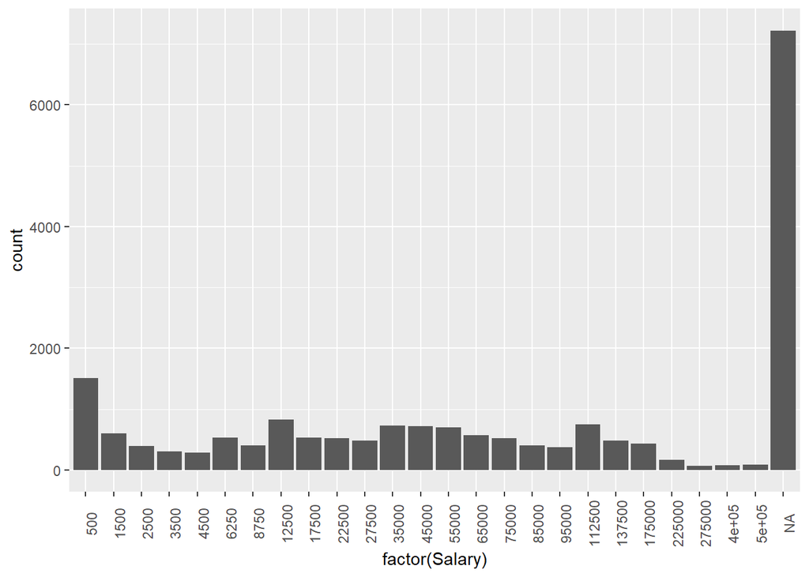

```r
df_basic %>% ggplot(aes(factor(Salary))) + geom_bar(stat = 'count') + theme(axis.text.x = element_text(angle = 90))
```

We see that the mode salary is extremely low, 500$. This is unexpected, and likely related to people filling out the survey who are not yet working as data scientists still labeling themself as a data scientist.

### Bivariate Plots

Now we will examine how age and compensation and gender and compensation vary together.

I plot these using mosaic plots, where the area of a rectangle represents the proportion of people falling into both groups.

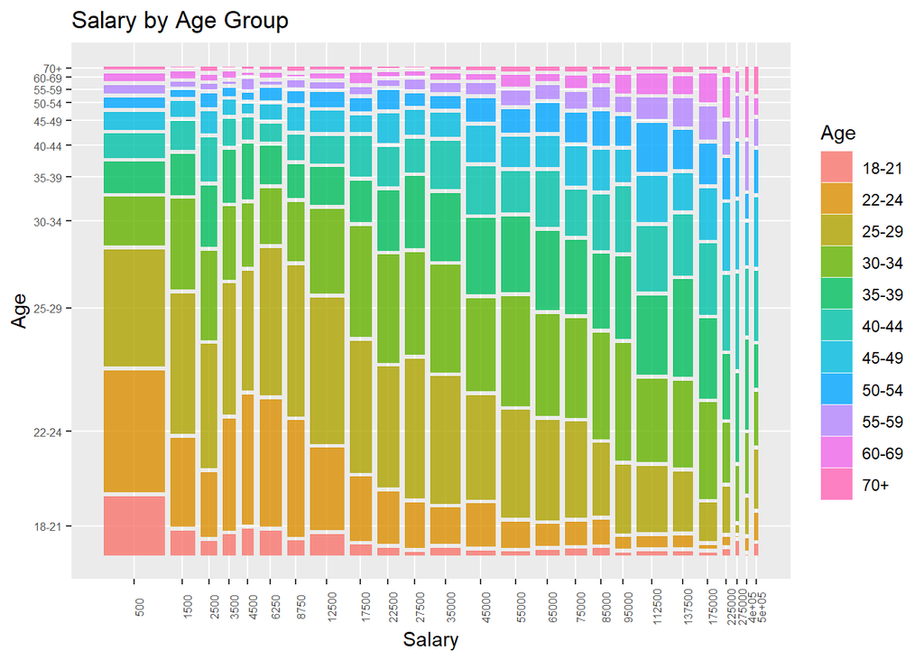

```r
df_basic %>%
  ggplot() +
  geom_mosaic(aes(x = product(Age, Salary), fill = Age), na.rm = TRUE) + xlab('Salary') + ylab('Age') + ggtitle('Salary by Age Group') + theme(axis.text = element_text(size = 6), axis.text.x = element_text(angle = 90))
```

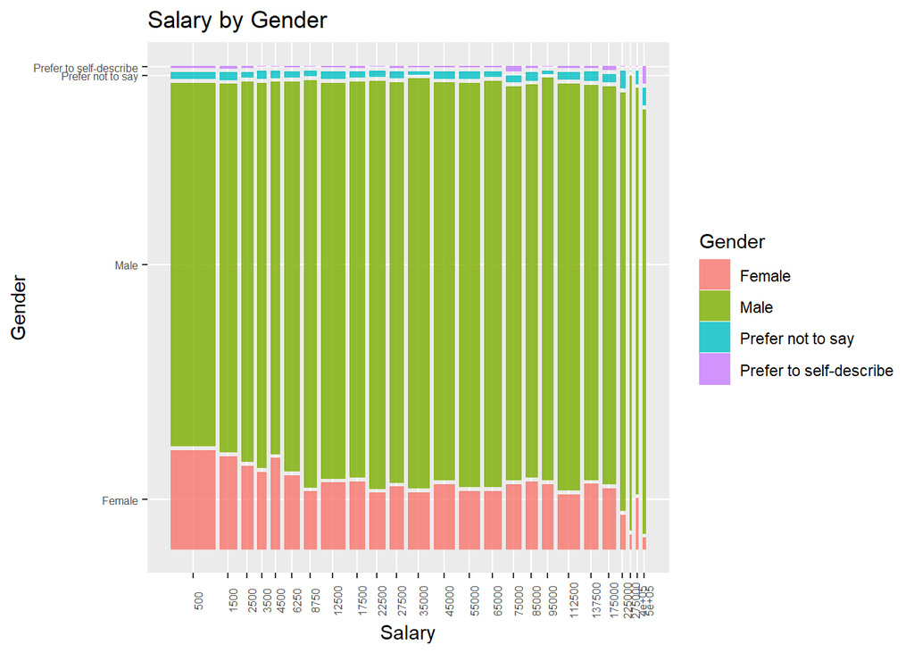

```r
df_basic %>%
  ggplot() +
  geom_mosaic(aes(x = product(Gender, Salary), fill = Gender), na.rm = TRUE) + xlab('Salary') + ylab('Gender') + ggtitle('Salary by Gender') + theme(axis.text = element_text(size = 6), axis.text.x = element_text(angle = 90))
```

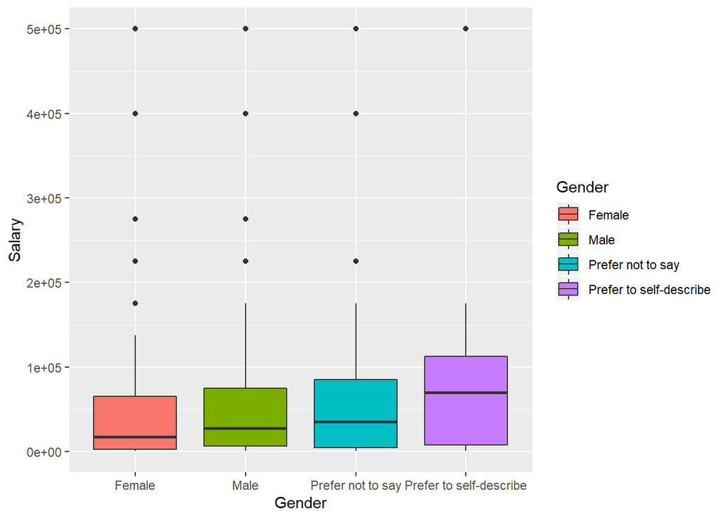

```r
df_basic %>% ggplot(aes(x = Gender, y = Salary, fill = Gender)) + geom_boxplot()
```

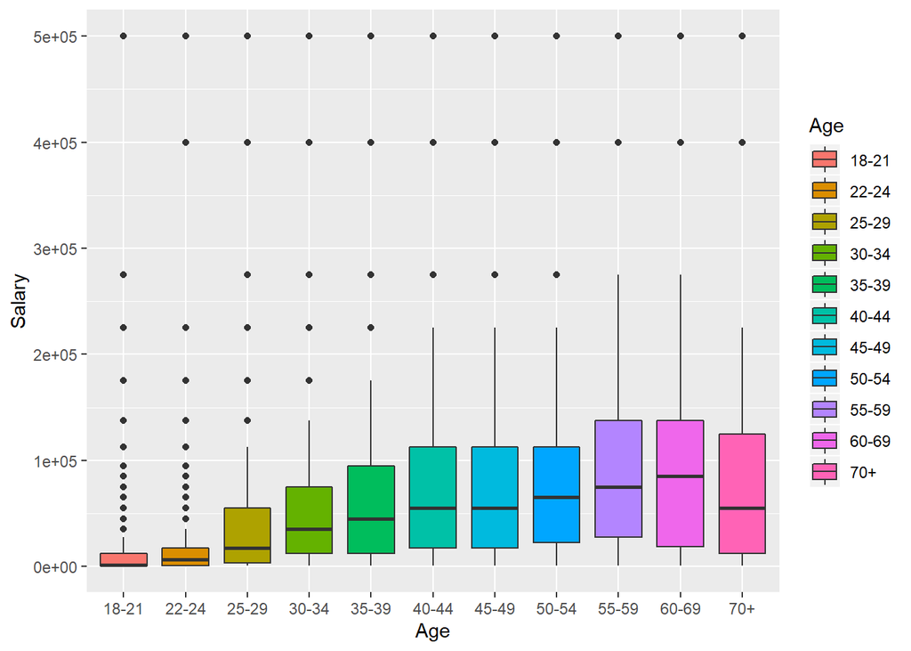

```r
df_basic %>% ggplot(aes(x = Age, y = Salary, fill = Age)) + geom_boxplot()
```

## Education, Country, and Experience vs. Salary

### Univariate Plots

First we get a feeling for each variable on its own via a bar plot. I am going to apply the same approach to years of experience to make it more useable in a plot.

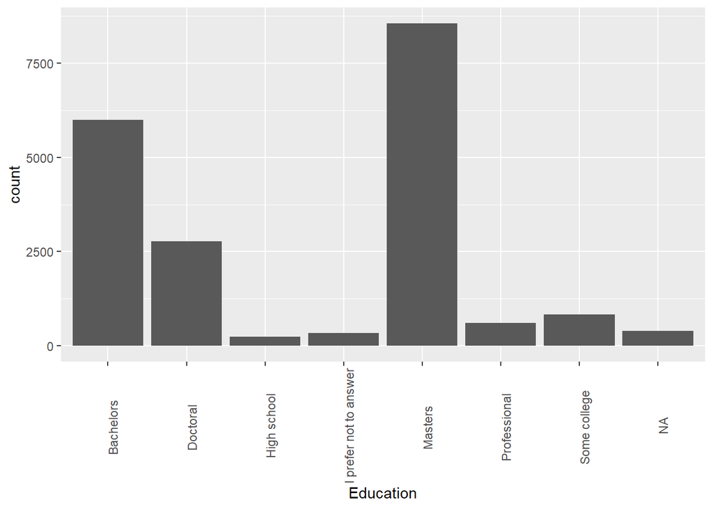

```r
df_basic$Education <- df_basic$Education %>% str_replace_all('Some collegeuniversity study without earning a bachelors', 'Some college') %>% str_replace_all('No formal education past high school', 'High school')

df_basic %>% ggplot(aes(x = Education)) + geom_bar(stat = 'count') + theme(axis.text.x = element_text(angle = 90))
```

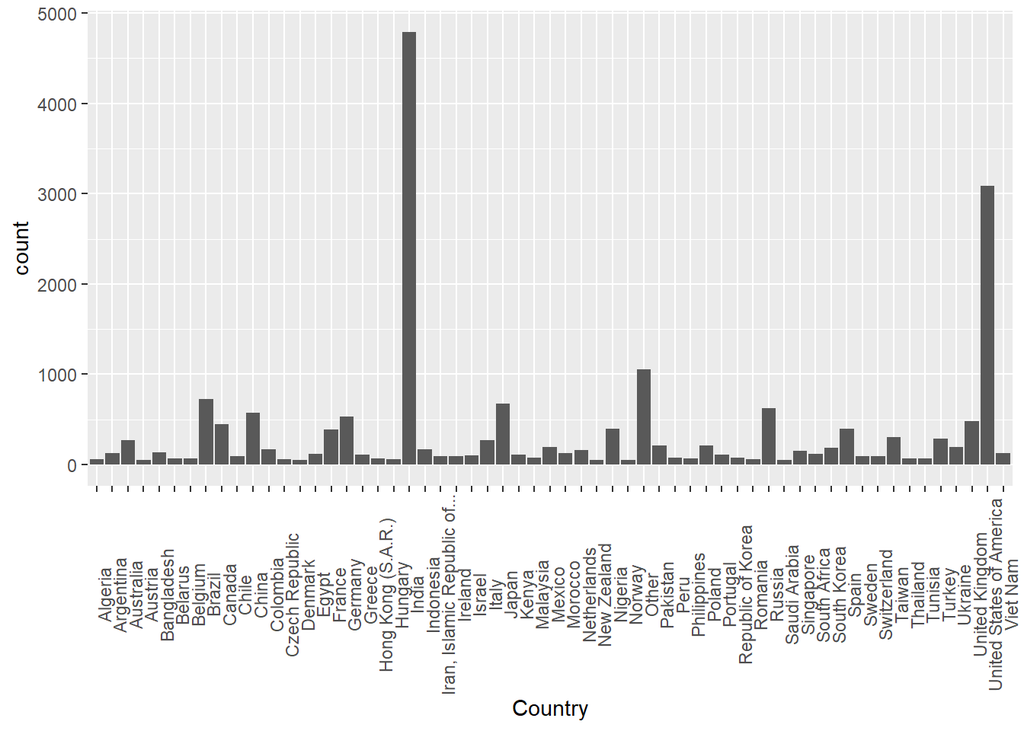

```r
##TODO REORDER BY COUNT, fix off tick labels
df_basic %>% ggplot(aes(x = Country)) + geom_bar(stat = 'count') + theme(axis.text.x = element_text(angle = 90))
```

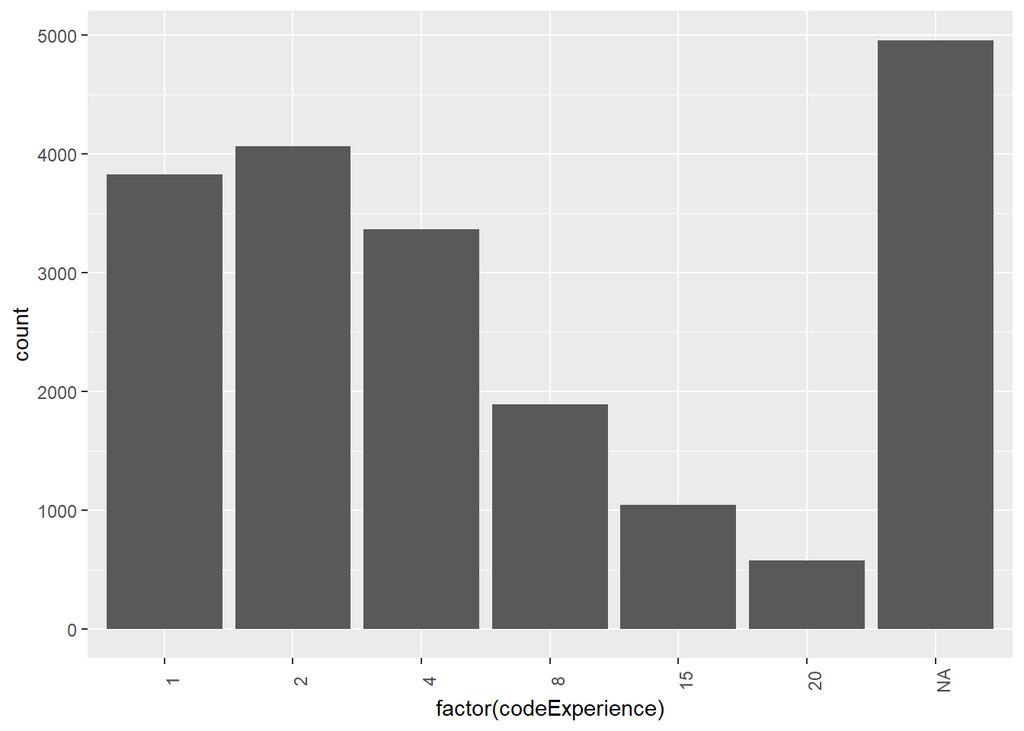

```r
df_basic$codeExperience<- clean_numeric_bins(df_basic$YearsOfCodeExperience)
df_basic %>% ggplot(aes(x = factor(codeExperience))) + geom_bar(stat = 'count') + theme(axis.text.x = element_text(angle = 90))
```

### Bivariate Plots

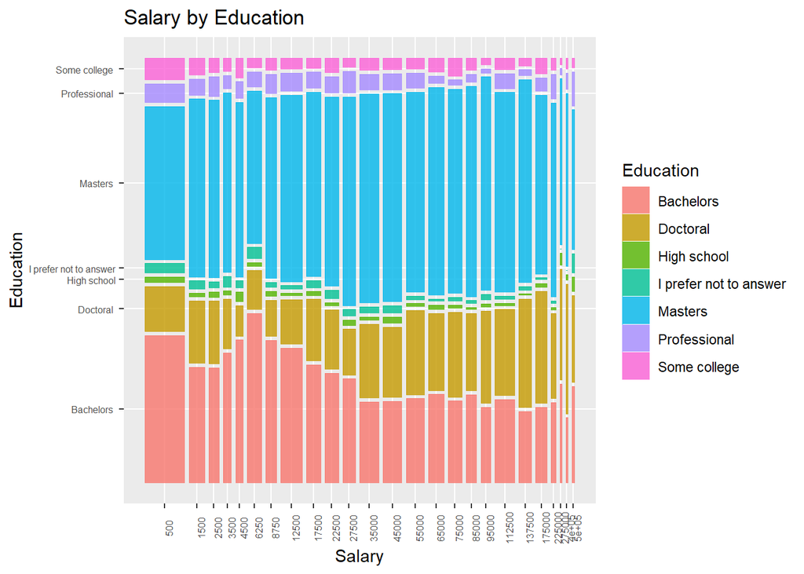

```r
df_basic %>%
  ggplot() +
  geom_mosaic(aes(x = product(Education, Salary), fill = Education), na.rm = TRUE) + xlab('Salary') + ylab('Education') + ggtitle('Salary by Education') + theme(axis.text = element_text(size = 6), axis.text.x = element_text(angle = 90))
```

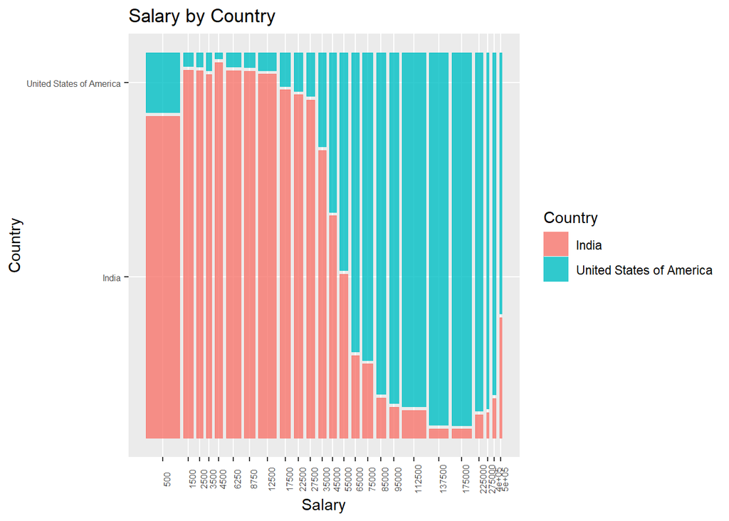

```r
india_us <- df_basic %>% filter(Country == 'United States of America'|Country == 'India')

india_us %>%
  ggplot() +
  geom_mosaic(aes(x = product(Country, Salary), fill = Country), na.rm = TRUE) + xlab('Salary') + ylab('Country') + ggtitle('Salary by Country') + theme(axis.text = element_text(size = 6), axis.text.x = element_text(angle = 90))
```

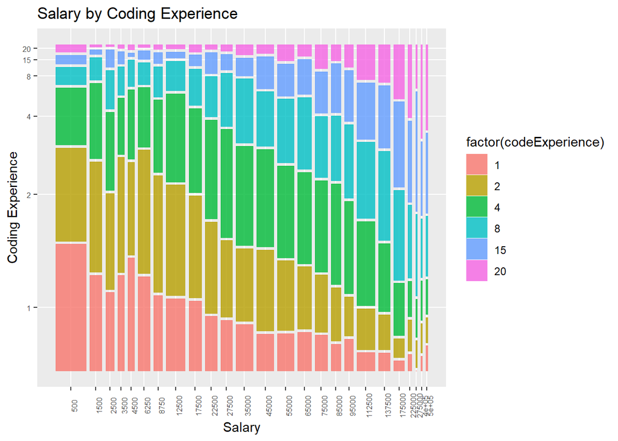

```r
df_basic %>%
  ggplot() +
  geom_mosaic(aes(x = product(factor(codeExperience), Salary), fill = factor(codeExperience)), na.rm = TRUE) + xlab('Salary') + ylab('Coding Experience') + ggtitle('Salary by Coding Experience') + theme(axis.text = element_text(size = 6), axis.text.x = element_text(angle = 90))
```

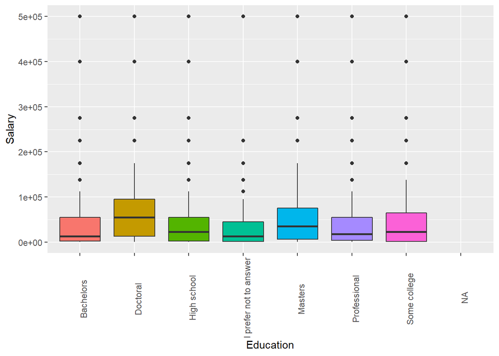

```r
df_basic %>% ggplot(aes(Education, Salary, fill = Education)) + geom_boxplot() + theme(axis.text.x = element_text(angle = 90), legend.position = 'None')
```

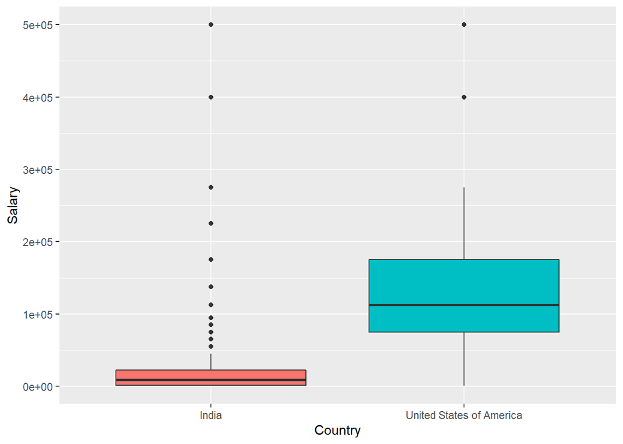

```r
india_us %>% ggplot(aes(Country, Salary, fill = Country)) + geom_boxplot() + theme(legend.position = 'None')
```

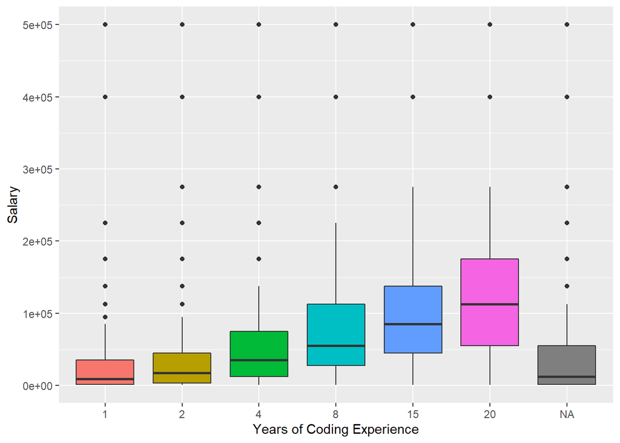

```r
df_basic %>% ggplot(aes(factor(codeExperience), Salary, fill = factor(codeExperience))) + geom_boxplot() + xlab('Years of Coding Experience') + theme(legend.position = 'None')
```

## Beyond the basic dataframe

We have lots of information broken down into many sub dataframes. I will attempt to access this information via a function rather than doing each dataframe individually.

```r
rm(india_us)

df_list <- list('df_ide', 'df_lang', 'df_viz', 'df_ml_algo', 'df_ml_tool', 'df_cv', 'df_nlp', 'df_cloud', 'df_cloud_prod', 'df_big_data', 'df_cloud_ml', 'df_db')
```

```r
### Function to summarize the smaller dataframes into medians and counts
summarize_df <- function(df_name){
  query <- paste('Select * from ', df_name, collapse = '')
  func_df <- dbGetQuery(conn, query)
  names(func_df) <- names(func_df) %>% str_remove_all("[/,-]") %>% str_replace_all('\\+', 'plus')
  titles <- c()
  med <- c()
  counts <- c()
  mega_df <- cbind(df_basic, func_df)

  colNames <- names(func_df)

  ## iterate through the columns of the dataframe
  ## each column is one skill
  for (j in colNames){
    ## Calculate the median and count for each column
    #mega_df[j] <- mega_df[j] %>% str_remove_all("[\\+,/,-]")
    meds <- mega_df %>% group_by_(j) %>% summarize(med = median(Salary, na.rm = T), count = n())
    titles <- append(titles, meds[[1]])
    med <- append(med, meds[[2]])
    counts <- append(counts, meds[[3]])
  }
  ##Create a dataframe of all skill names, medians, counts
  return(data.frame('skill' = titles, 'medians' = med, 'counts' = counts))
}
```

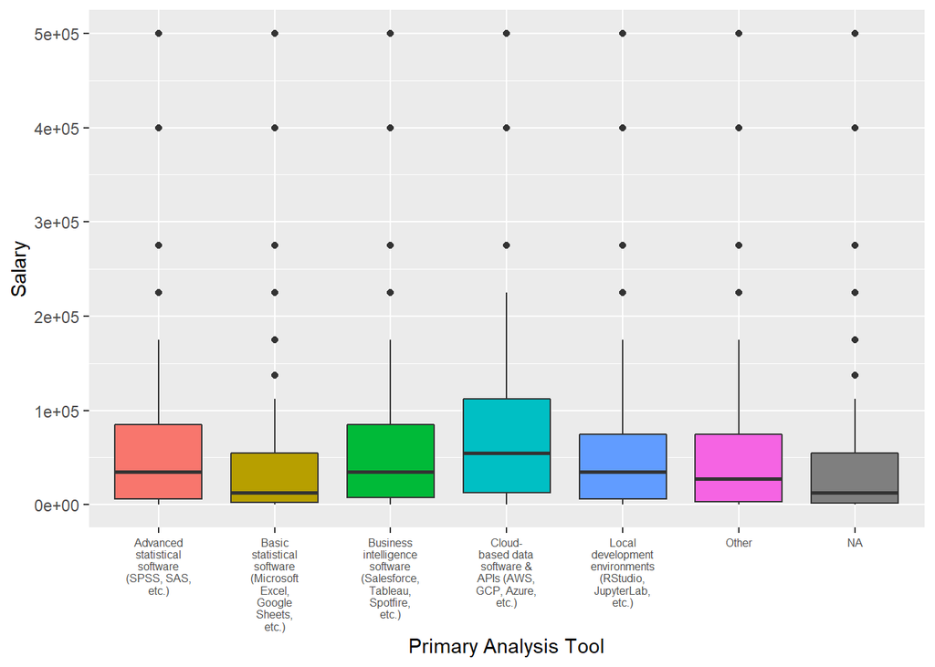

```r
##Plot side dataframes that are in slightly different format

df_prime_tool <- dbGetQuery(conn, 'Select * from df_prime_tool')
cbind(df_basic, df_prime_tool) %>% ggplot(aes(x = str_wrap(primary_analysis_tool, 12), y = Salary, fill = primary_analysis_tool)) + geom_boxplot() + theme(axis.text.x = element_text(size = 6), legend.text = element_text(size = 6)) + xlab('Primary Analysis Tool') + theme(legend.position = 'none')
```

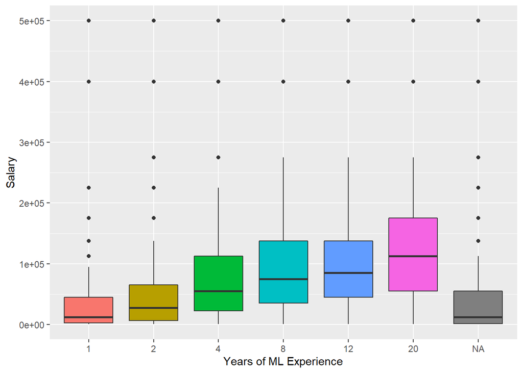

```r
df_ml_xp <- dbGetQuery(conn, 'Select * from df_ml_xp')
df_ml_xp$ml_exp_years <- clean_numeric_bins(df_ml_xp$ml_exp_years)
cbind(df_basic, df_ml_xp) %>% ggplot(aes(x = factor(ml_exp_years), y = Salary, fill = factor(ml_exp_years))) + geom_boxplot() + xlab('Years of ML Experience') + theme(legend.position = 'None')
```

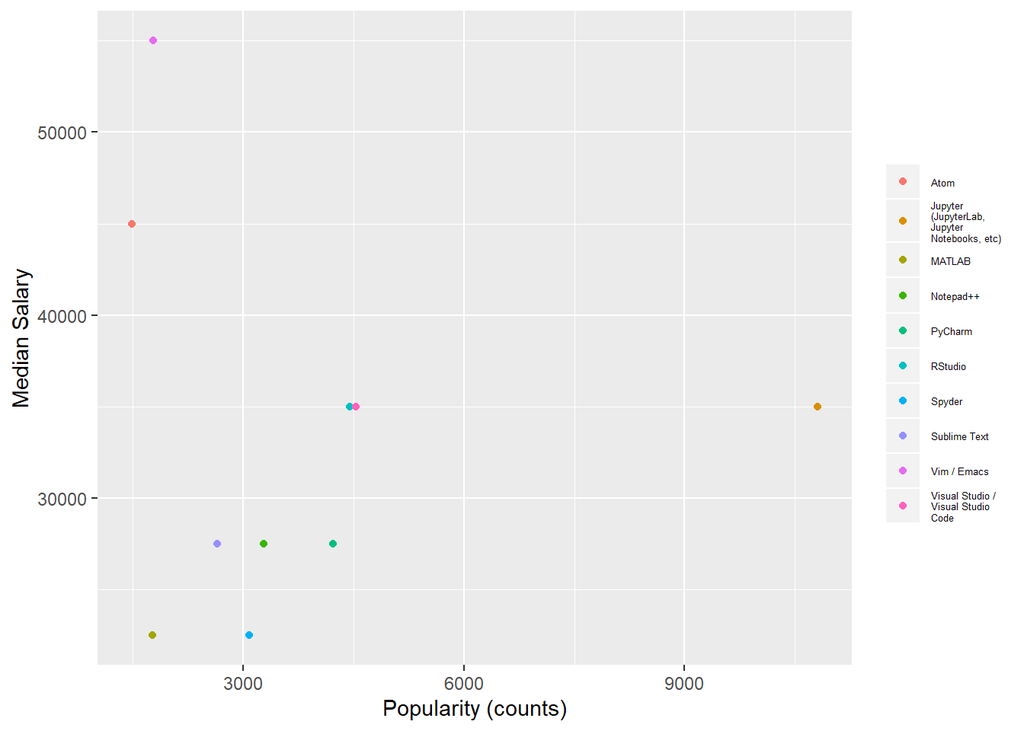

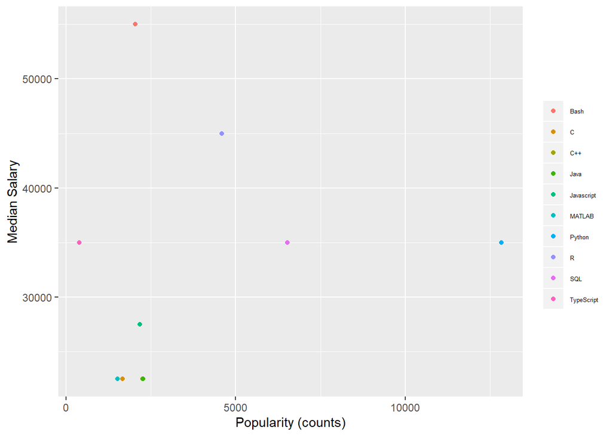

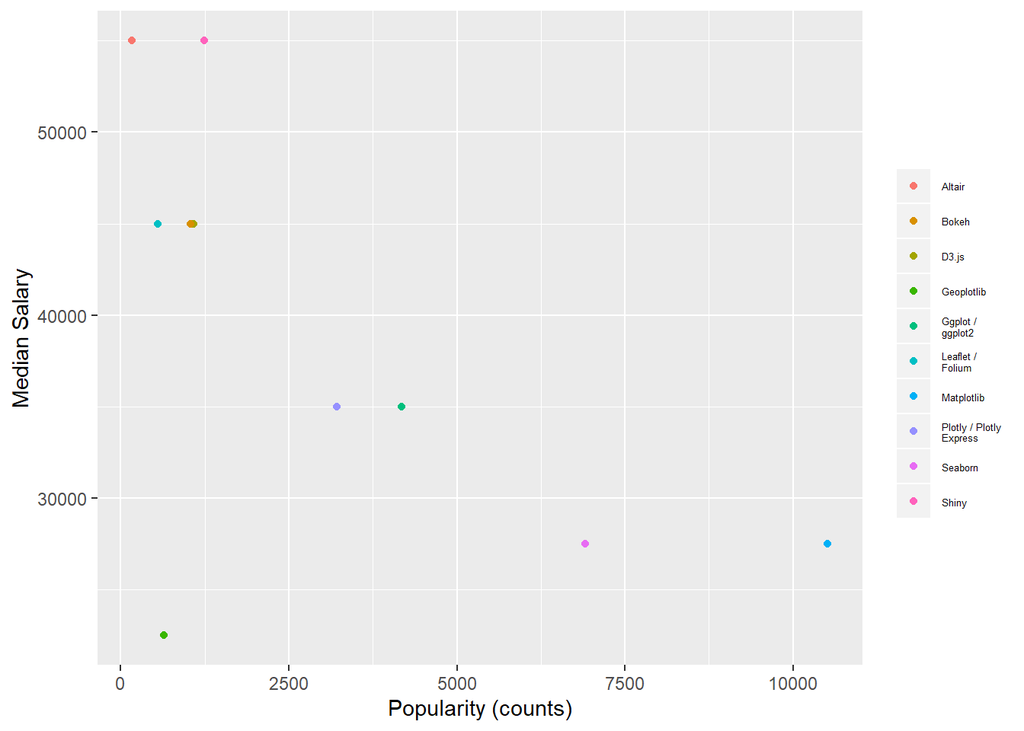

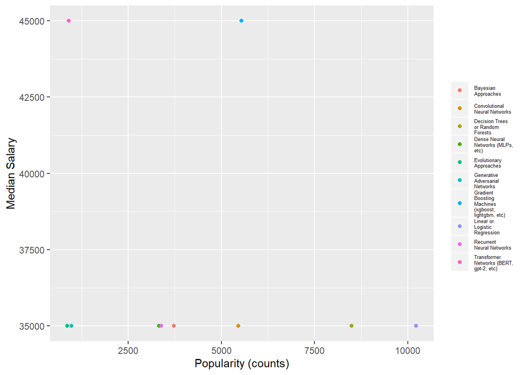

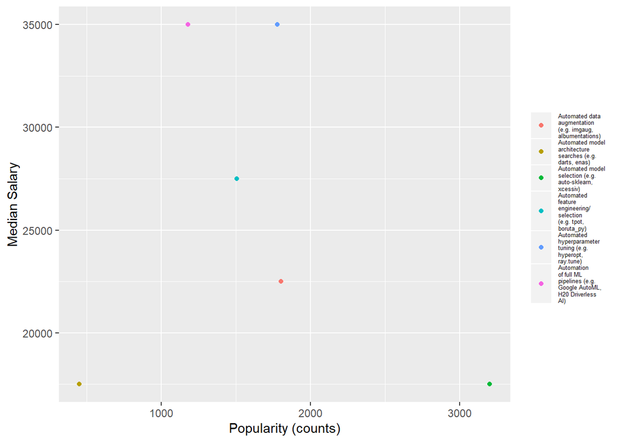

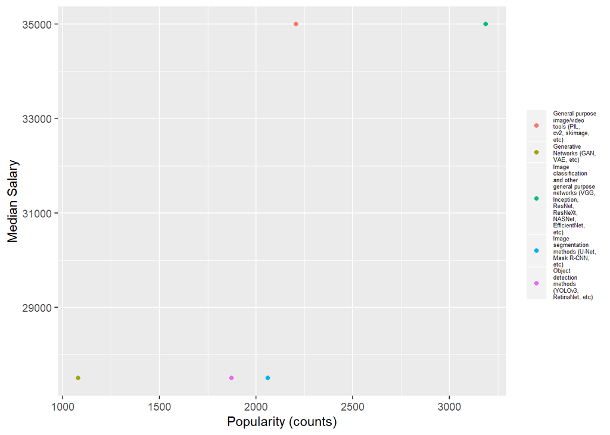

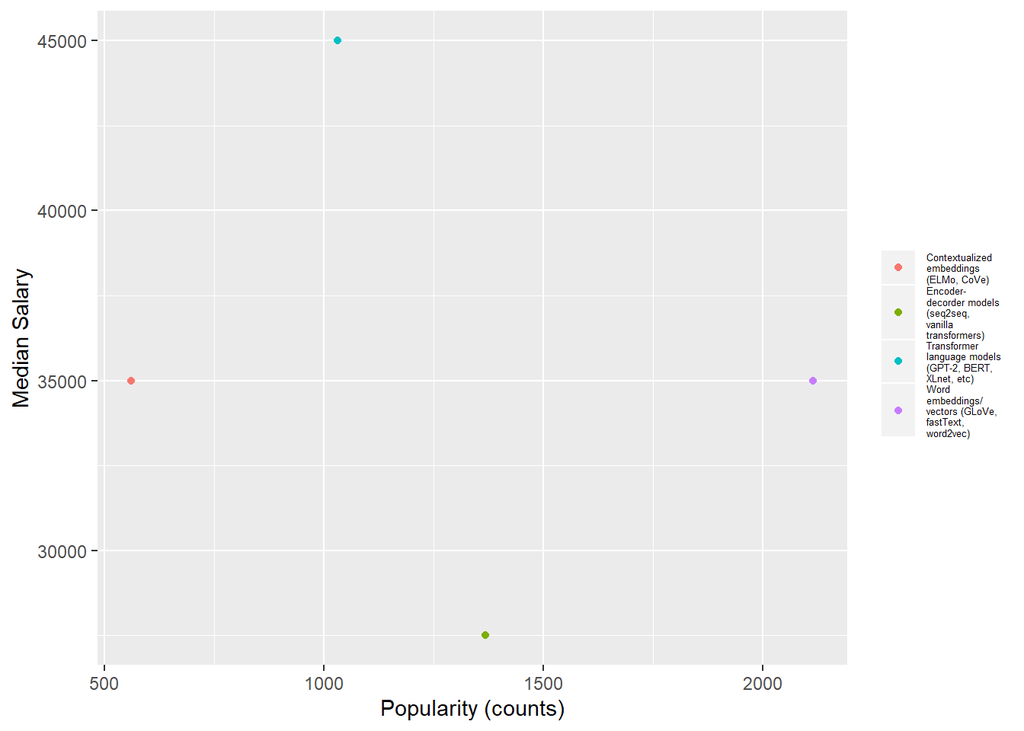

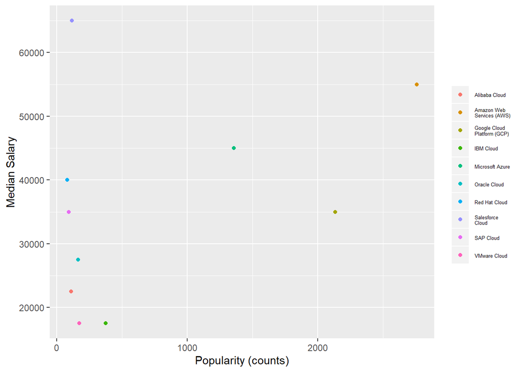

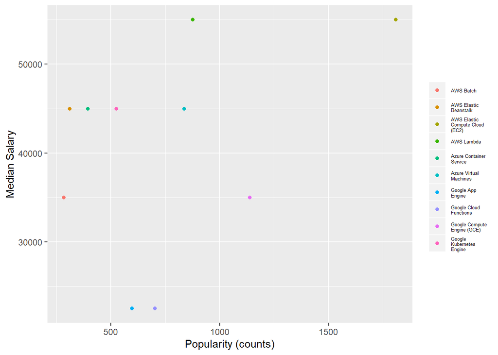

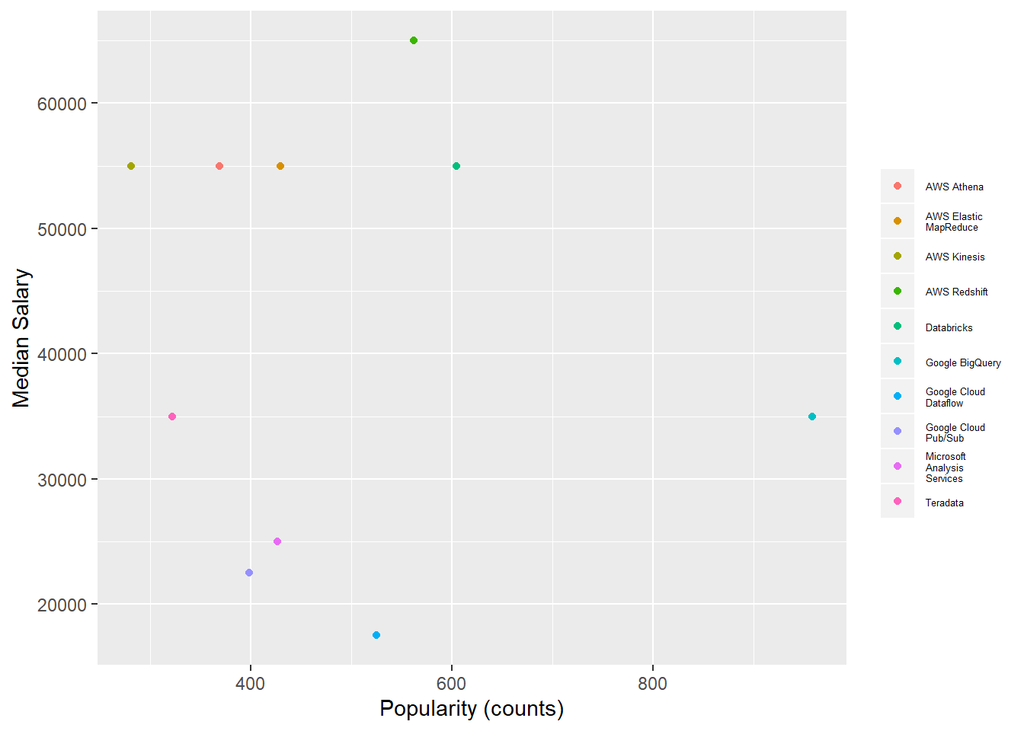

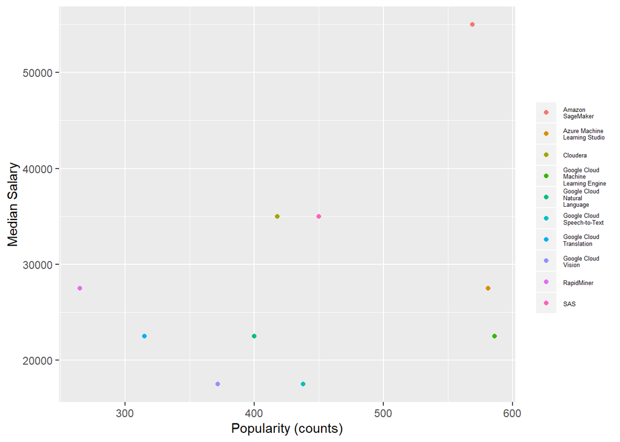

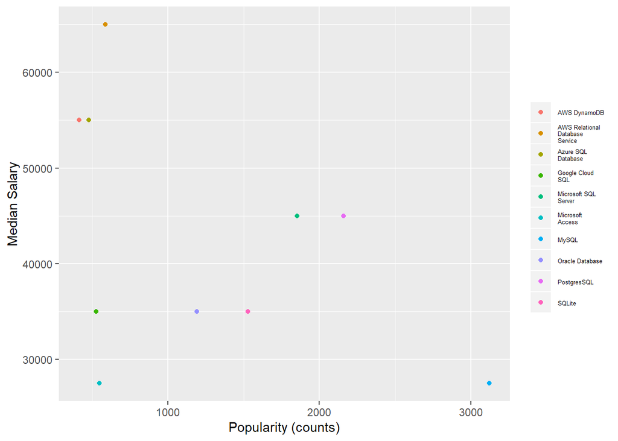

```r
##Plot other side dataframes using function created.
for (i in df_list){
  winnerdf <- summarize_df(i)
  winnerdf <- winnerdf %>% filter(!(skill %in% c('None', 'Other'))) %>% filter(!(is.na(skill)))

  plots <- winnerdf %>% ggplot(aes(counts, medians, color = str_wrap(skill, 15))) + geom_point() + theme(legend.text = element_text(size = 5), legend.title = element_blank()) + xlab('Popularity (counts)') +ylab('Median Salary')
  print(plots)
}
```